# Zadanie 2

Aleksander Jasiński

2025-03-17

# Część I

Sprawdźmy jak zmienia się moc testów próbek losowanych z rozkładu testu t-Studenta w zależności od: - liczby danych - liczby stopni swobody generowanego rozkładu

Losowanie próbek będziemy powtarzać 100 razy. Niech nasza liczność (`n`) oraz stopnie swobody (`df`) przyjmują następujące wartości:

```
## [1] "Liczność: "
```

```
## [1]  10  50 100 500
```

```
## [1] "St. swobody: "
```

```
## [1]  5 10 30
```

Założenia naszych testów:

$\\ H_{0}: próbka\ pochodzi\ z\ rozkladu\ normalnego$

$\\ H_{1}: próbka\ pochodzi\ z\ rozkladu\ nienormalnego$

**Test Chi2** porównuje wartości w przedziale. Dla liczności przedziału mniejszej niż 5 nasze wyniki mogą być nieadekwatne, dlatego przy wielkości próbki n=10 otrzymujemy wartość NA (R wyrzuca `warnings` przy próbie wyliczenia). Dzięki temu unikamy błędnych wniosków, które mogłyby płynąć ze wspomnianych małych próbek.

Oto wyniki testu `Shapiro-Wilka`, `KS` oraz `chi2` w zależności od liczności oraz st. swobody:

```r
wyniki_shapiro
```

```
##      n df pvalue
## 1   10  5 0.7277
## 2   50  5 0.0777
## 3  100  5 0.0759
## 4  500  5 0.0001
## 5   10 10 0.3687
## 6   50 10 0.5075
## 7  100 10 0.3325
## 8  500 10 0.0273
## 9   10 30 0.4662
## 10  50 30 0.4107
## 11 100 30 0.9708
## 12 500 30 0.1112
```

```r
wyniki_ks
```

```
##      n df pvalue
## 1   10  5 0.3183
## 2   50  5 0.0541
## 3  100  5 0.8233
## 4  500  5 0.4943
## 5   10 10 0.7015
## 6   50 10 0.6298
## 7  100 10 0.3456
## 8  500 10 0.1148
## 9   10 30 0.2363
## 10  50 30 0.3541
## 11 100 30 0.3351
## 12 500 30 0.6154
```

```r
wyniki_chi2
```

```
##      n df pvalue
## 1   10  5     NA
## 2   50  5 0.0087
## 3  100  5 0.6092
## 4  500  5 0.4540
## 5   10 10     NA
## 6   50 10 0.0663
## 7  100 10 0.4932
## 8  500 10 0.2022
## 9   10 30     NA
## 10  50 30 0.1991
## 11 100 30 0.5918
## 12 500 30 0.8337
```

Przeprowadźmy `N` (100) losowań `n-elementowych` z rozkładu t-Studenta z `df` stopniami swobody próbek i sprawdźmy jak zmienia się moc testu:

```
##     n df power
## 1  10  5  0.11
## 2  50  5  0.41
## 3 100  5  0.51
## 4 500  5  1.00
## 5  10 10  0.08
## 6  50 10  0.19
```

```
##     n df power
## 1  10  5  0.04
## 2  50  5  0.05
## 3 100  5  0.04
## 4 500  5  0.03
## 5  10 10  0.03
## 6  50 10  0.06
```

```
##     n df power
## 1  10  5   NaN
## 2  50  5  0.07
## 3 100  5  0.08
## 4 500  5  0.04
## 5  10 10   NaN
## 6  50 10  0.03
```

#### Analiza

Wraz ze wzrostem stopni swobody rozkład t-Studenta zaczyna przypominać rozkład normalny, dlatego dla ujednolicenia naszych obserwacji i zobrazowania zmienności mocy testu w zależności od stopni swobody **przefiltrujmy nasze dane dla `df=10`**.

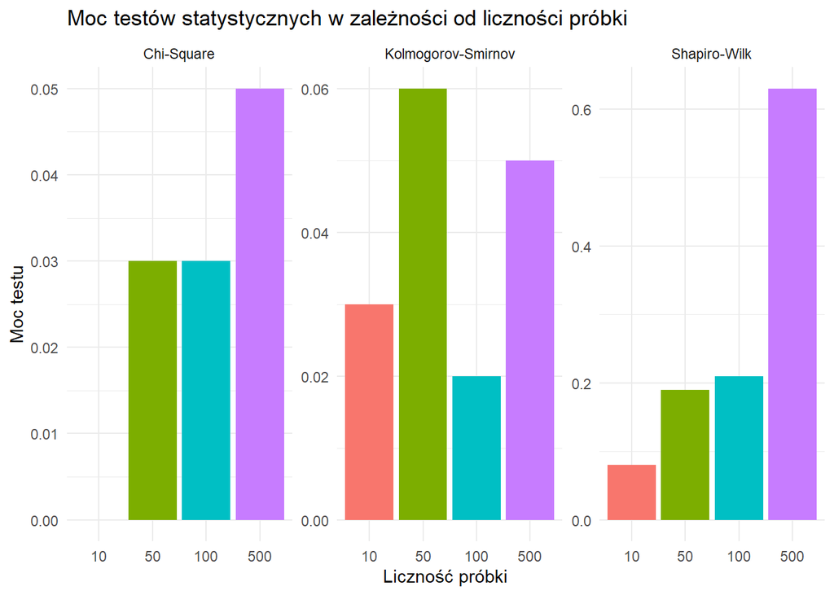

- Najlepszy test do wykrywania nienormalności w tym przypadku to **test Shapiro-Wilka**. Wraz ze wzrostem liczności próbki rośnie jego moc testu.
- Moc KS jest znacznie niższa niż Shapiro-Wilka, co sugeruje, że **nie jest idealny do wykrywania różnic między t-Studentem** (`df = 10`) a rozkładem normalnym.
- Test ten wymaga odpowiedniego podziału na kategorie i dostatecznej liczby obserwacji w każdej kategorii, dlatego właśnie nie byliśmy w stanie wykonać go dla próbki o liczności 10, a w przypadku pozostałych próbek możemy zauważyć brak monotonicznego wzrostu mocy testu.

Zwizualizujmy sobie jeszcze przypadek z danymi przefiltrowanymi dla `df=30`:

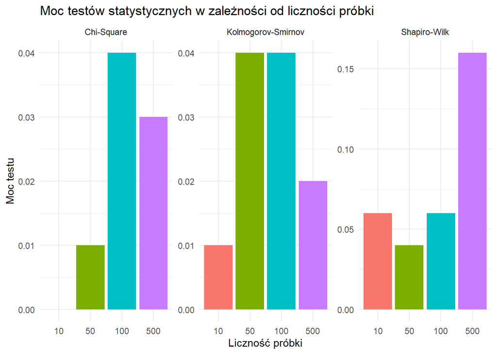

**Analiza wpływu stopni swobody**

Sprawdźmy uśrednioną moc testu dla naszych testów. W tym przypadku przefiltrujmy dane dla próbki o wielkości `n=50`:

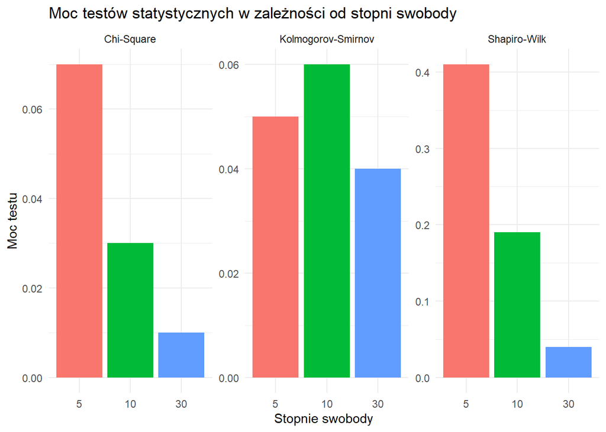

- Wraz ze wzrostem stopni swobody maleje moc testu. Niestabilność w tym przypadku wykazuje test KS.
- Chi2 i Kolmogorov-Smirnov wydają się bardziej stabilne w porównaniu do Shapiro-Wilka, który traci moc wraz ze wzrostem stopni swobody.
- Test Shapiro-Wilka jest bardzo skuteczny dla małych stopni swobody, ale jego moc szybko maleje.

# Część II:

Niech

$alpha=0.05$

W tej części zobaczmy ile wynosi odsetek odrzuceń prawdziwej $H_{0}$ w teście KS oraz chi2. Próbkę będziemy losować z rozkładu chi2 o `df` stopniach swobody. Następnie otrzymane wyniki porównamy z wynikami testów metodą **Probability Integral Transform**.

**Uwaga:** Tak jak zostało wspomniane wcześniej, dla małych próbek test chi-kwadrat może działać niepoprawnie,. Każda kategoria powinna mieć oczekiwaną liczebność co najmniej 5. W przeciwnym razie aproksymacja rozkładem chi-kwadrat może być błędna o czym informuje nas sam R.

```r
kable(moc2)
```

| n | df | pval_ks | pval_pit_ks | pval_chi2 | pval_pit_chi2 |
| --- | --- | --- | --- | --- | --- |
| 10 | 5 | 0.3853435 | 0.3853435 | 0.2841687 | 0.2872975 |
| 50 | 5 | 0.0277455 | 0.0277455 | 0.0204003 | 0.0668816 |
| 100 | 5 | 0.7646380 | 0.7646380 | 0.9530474 | 0.9114125 |
| 500 | 5 | 0.4938527 | 0.4938527 | 0.0613859 | 0.9638103 |
| 10 | 10 | 0.3342261 | 0.3342261 | 0.0037252 | 0.2213854 |
| 50 | 10 | 0.3873249 | 0.3873249 | 0.3930059 | 0.1585976 |
| 100 | 10 | 0.5360329 | 0.5360329 | 0.2458215 | 0.2022677 |
| 500 | 10 | 0.4265727 | 0.4265727 | 0.0511598 | 0.0183776 |
| 10 | 30 | 0.5722690 | 0.5722690 | 0.2778711 | 0.2872975 |
| 50 | 30 | 0.8810267 | 0.8810267 | 0.9921384 | 0.7791877 |
| 100 | 30 | 0.5421710 | 0.5421710 | 0.8331957 | 0.1223252 |
| 500 | 30 | 0.0835926 | 0.0835926 | 0.1098576 | 0.1841625 |

- Test KS na surowej próbce i test PIT na transformowanych wartościach dają identyczne `p-value`.
- Test PIT ma bardziej “ciągłą” skalę niż histogram.
- Transformacja **PIT zmienia wyniki testu chi2**.

w przypadku metody PIT jeżeli dane rzeczywiście pochodzą z rozkładu chi2 to wartości $U_{i}$ powinny być rozłożone zgodnie z rozkładem jednostajnym na $[0;1]$. Dlatego też wartości testu KS oraz testu KS z uwzględnieniem metody PIT są identyczne.

Obliczmy moc statystyczną dla naszych testów:

```
##      n df power_ks power_pit_ks power_chi2 power_pit_chi2
## 1   10  5     0.03         0.03       0.12           0.01
## 2   50  5     0.06         0.06       0.18           0.05
## 3  100  5     0.02         0.02       0.15           0.06
## 4  500  5     0.04         0.04       0.19           0.04
## 5   10 10     0.08         0.08       0.16           0.03
## 6   50 10     0.02         0.02       0.17           0.03
## 7  100 10     0.02         0.02       0.19           0.05
## 8  500 10     0.03         0.03       0.22           0.08
## 9   10 30     0.08         0.08       0.18           0.01
## 10  50 30     0.03         0.03       0.15           0.03
## 11 100 30     0.10         0.10       0.25           0.09
## 12 500 30     0.05         0.05       0.23           0.06
```

```r
filtered_data <- subset(moc2, df==10)
filtered_data_long <- filtered_data %>%
  pivot_longer(cols = c(power_ks, power_pit_ks),
               names_to = "Test",
               values_to = "Odsetek")
```

Wykres 1:

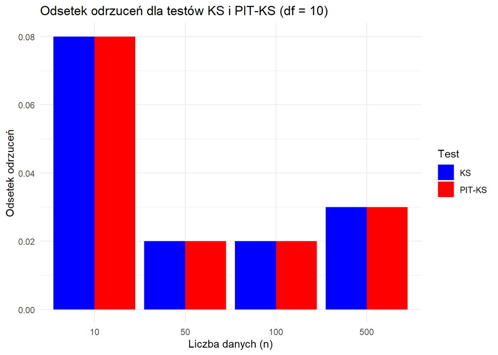

Wykres2:

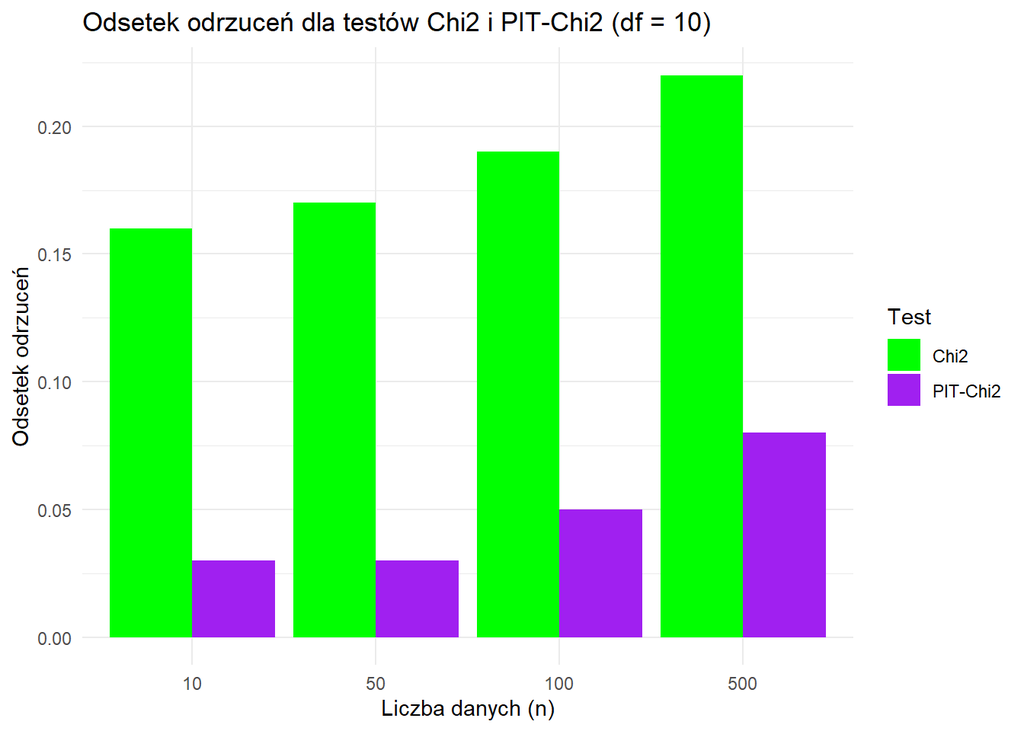

# Część III

Zbadajmy moc testu Kołmogorowa-Smirnowa dla próbek z rozkładu chi2 o różnych stoniach swobody, manipulując danymi tak żeby wszystkie posiadały taką samą wartość oczekiwaną. W rozkładzie chi2 zachodzi równość:

$E(X)=k$

czyli wartość oczekiwana jest równa liczbie stopni swobody.

```r
w1 <- moc_ks %>% group_by(n) %>%
  summarize(mean_power=mean(power))
kable(w1)
```

| n | mean_power |
| --- | --- |
| 10 | 0.5466667 |
| 50 | 0.7011111 |
| 100 | 0.6911111 |
| 500 | 0.6877778 |

Pierwszym zauważalnym wnioskiem, który możemy zauważyć jest fakt, że wraz ze wzrostem liczności próbki wartość mocy testu stabylizuje się wokół $0.69$.

Wizualizacja:

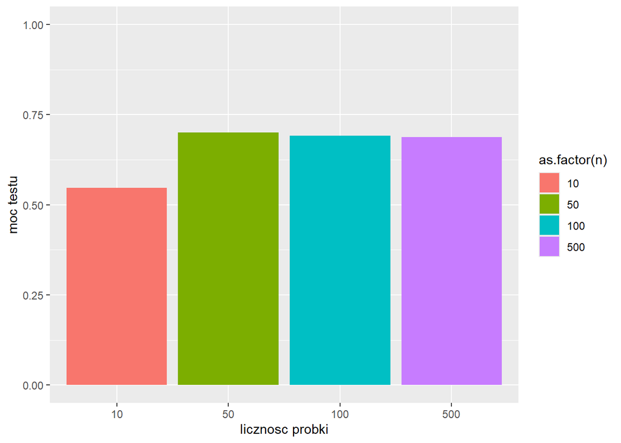

Sprawdźmy czy moc testu rośnie jeśli faktycznie `df1==df2`:

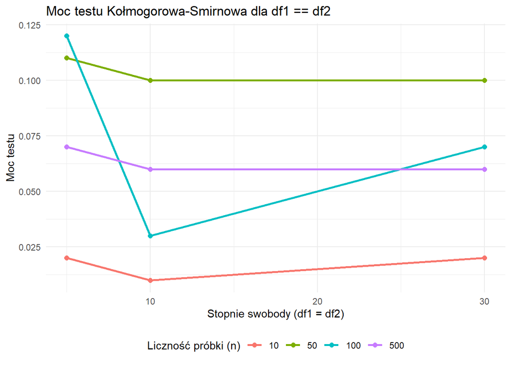

Sprawdźmy jak wygląda sytuacja kiedy `df1!=df2`:

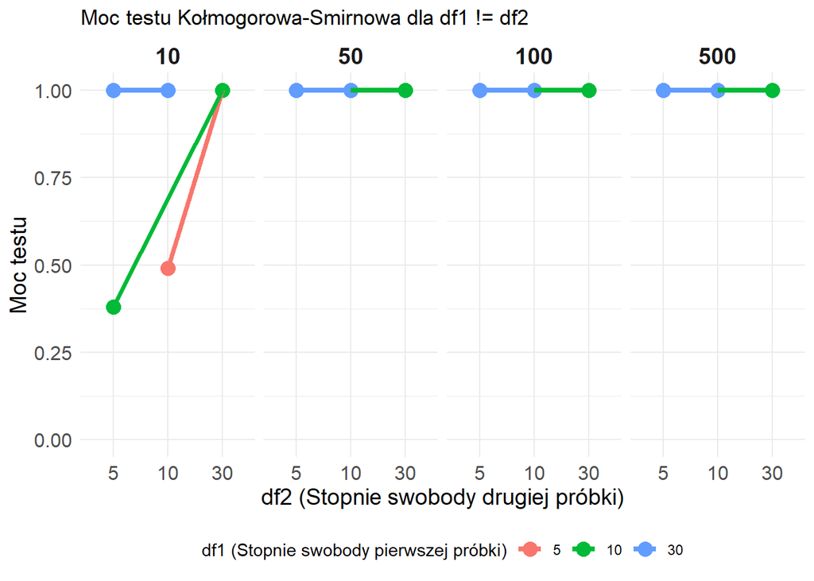

#### Wnioski:

- Dla małych próbek moc testu mocno zależy od różnicy między df1 i df2
- Dla większych próbek moc testu wynosi 1, czyli **test Kołmogorowa-Smirnowa** prawie zawsze wykrywa różnice między tymi rozkładami
- Nawet jeśli będziemy mieli nieznaczną różnicę pomiędzy naszymi próbkami to dla `n>=50` test KS będzie ją wkrywał, nie zawsze jest to porządany przez nas rezultat.

Wyszczególnijmy sobie jezcze przypadek, gdy `df1==5`, ponieważ na wykresie powyżej nie jest on widoczny:

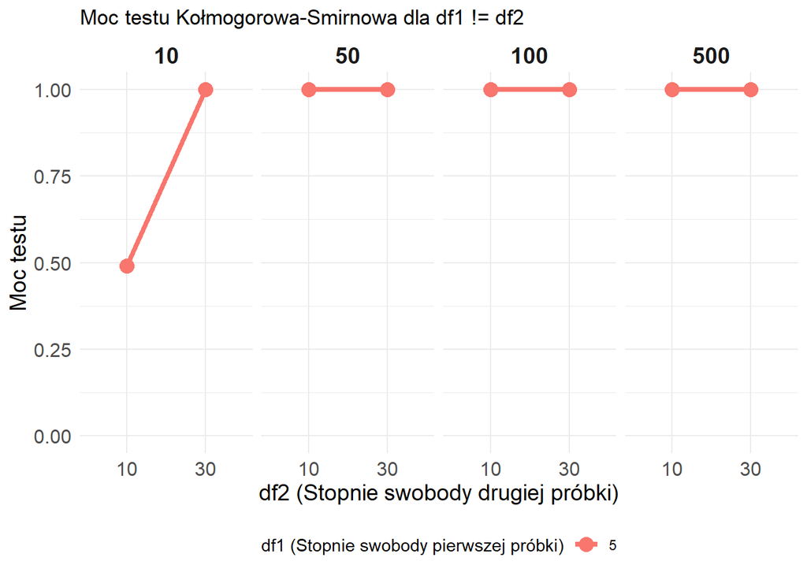

# Część IV

Sprawdźmy wpływ liczby klas (`breaks`) na odsetek odrzuceń hipotezy zerowej w teście chi2 przy weryfikacji zgodności z rozkładem chi2.

Pamiętajmy, że dla małych prób (`n=10`) nasz test może mieć dużą zmienność i prowadzić do “fałszywych” odrzuceń.

Wizualizacja wyników:

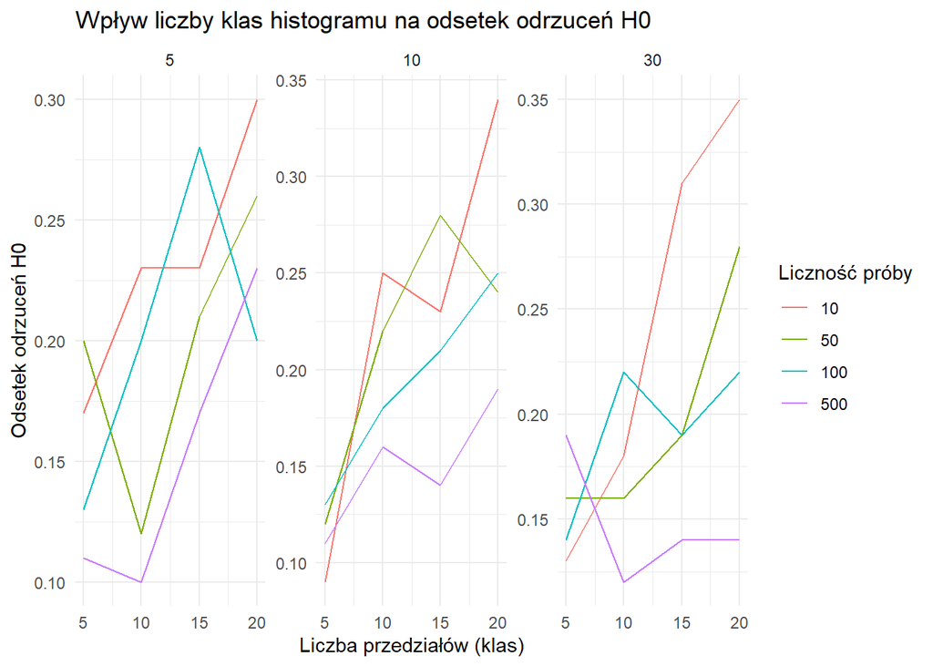

Sprawdźmy wpływ samej wielkości próbki oraz liczby klas przyjmując `df=10`:

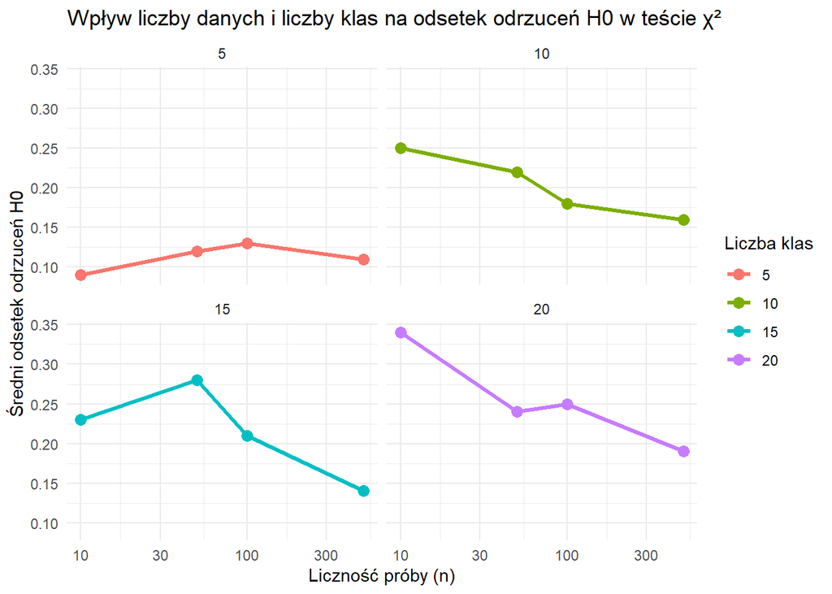

#### Wnioski

- Dla małych prób możemy zauważyć **większą wariancję**
- Optymalna liczba klas zależy od wielkości próbki. Dla małych próbek lepiej stosować mniej klas, dla dużych można ich używać więcej.
- Zbyt mała liczba klas może ukrywać różnice, a zbyt duża powodować problemy z niskimi oczekiwanymi licznościami.

Sprawdźmy wpływ stopni swobody oraz liczby klas przyjmując `n=50`:

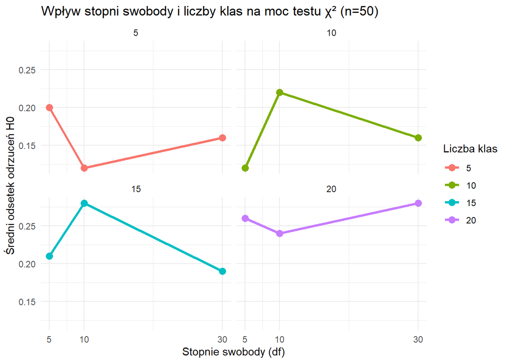